# Avances2.7

Andre Jo 22199, Nelson Escalante 22046

2025-05-03

## Introducción

En el presente trabajo, se tiene como objetivo construir y evaluar modelos predictivos utilizando el algoritmo de Máquinas de Vectores de Soporte (SVM) para clasificar propiedades inmobiliarias según su precio en tres categorías: barata, media y cara. Para ello, se emplearán los mismos conjuntos de datos de entrenamiento y prueba utilizados en trabajos previos, asegurando la consistencia en las evaluaciones.

En primer lugar, se realizará un análisis exploratorio de los datos para identificar las transformaciones necesarias y garantizar que las características sean adecuadas para el entrenamiento del modelo SVM. Se utilizará como variable de respuesta una categorización del precio de las casas, lo que permitirá desarrollar un modelo de clasificación.

A continuación, se llevará a cabo una exploración general de los datos, utilizando herramientas como las cajas de bigote para visualizar la distribución de las variables y detectar posibles valores atípicos.

```
##     Id SalePrice economico medio caro
## 1 1461  169277.1         1     0    0
## 2 1462  187758.4         0     1    0
## 3 1463  183583.7         1     0    0
## 4 1464  179317.5         1     0    0
## 5 1465  150730.1         1     0    0
## 6 1466  177151.0         1     0    0
```

```
##   Id MSSubClass MSZoning LotFrontage LotArea Street Alley LotShape LandContour
## 1  1         60       RL          65    8450   Pave  <NA>      Reg         Lvl
## 2  2         20       RL          80    9600   Pave  <NA>      Reg         Lvl
## 3  3         60       RL          68   11250   Pave  <NA>      IR1         Lvl
## 4  4         70       RL          60    9550   Pave  <NA>      IR1         Lvl
## 5  5         60       RL          84   14260   Pave  <NA>      IR1         Lvl
## 6  6         50       RL          85   14115   Pave  <NA>      IR1         Lvl
##   Utilities LotConfig LandSlope Neighborhood Condition1 Condition2 BldgType
## 1    AllPub    Inside       Gtl      CollgCr       Norm       Norm     1Fam
## 2    AllPub       FR2       Gtl      Veenker      Feedr       Norm     1Fam
## 3    AllPub    Inside       Gtl      CollgCr       Norm       Norm     1Fam
## 4    AllPub    Corner       Gtl      Crawfor       Norm       Norm     1Fam
## 5    AllPub       FR2       Gtl      NoRidge       Norm       Norm     1Fam
## 6    AllPub    Inside       Gtl      Mitchel       Norm       Norm     1Fam
##   HouseStyle OverallQual OverallCond YearBuilt YearRemodAdd RoofStyle RoofMatl
```

[output cut: 69 more lines]

```
##        Id         MSSubClass       MSZoning          LotFrontage
##  Min.   :1461   Min.   : 20.00   Length:1459        Min.   : 21.00
##  1st Qu.:1826   1st Qu.: 20.00   Class :character   1st Qu.: 58.00
##  Median :2190   Median : 50.00   Mode  :character   Median : 67.00
##  Mean   :2190   Mean   : 57.38                      Mean   : 68.58
##  3rd Qu.:2554   3rd Qu.: 70.00                      3rd Qu.: 80.00
##  Max.   :2919   Max.   :190.00                      Max.   :200.00
##                                                     NA's   :227
##     LotArea         Street             Alley             LotShape
##  Min.   : 1470   Length:1459        Length:1459        Length:1459
##  1st Qu.: 7391   Class :character   Class :character   Class :character
##  Median : 9399   Mode  :character   Mode  :character   Mode  :character
##  Mean   : 9819
##  3rd Qu.:11518
##  Max.   :56600
##
##  LandContour         Utilities          LotConfig          LandSlope
##  Length:1459        Length:1459        Length:1459        Length:1459
##  Class :character   Class :character   Class :character   Class :character
##  Mode  :character   Mode  :character   Mode  :character   Mode  :character
##
##
##
##
##  Neighborhood        Condition1         Condition2          BldgType
##  Length:1459        Length:1459        Length:1459        Length:1459
##  Class :character   Class :character   Class :character   Class :character
##  Mode  :character   Mode  :character   Mode  :character   Mode  :character
##
##
##
##
##   HouseStyle         OverallQual      OverallCond      YearBuilt
##  Length:1459        Min.   : 1.000   Min.   :1.000   Min.   :1879
##  Class :character   1st Qu.: 5.000   1st Qu.:5.000   1st Qu.:1953
##  Mode  :character   Median : 6.000   Median :5.000   Median :1973
##                     Mean   : 6.079   Mean   :5.554   Mean   :1971
##                     3rd Qu.: 7.000   3rd Qu.:6.000   3rd Qu.:2001
##                     Max.   :10.000   Max.   :9.000   Max.   :2010
##
```

[output cut: 105 more lines]

```
##  Length:1459        Length:1459        Length:1459        Min.   :    0.00
##  Class :character   Class :character   Class :character   1st Qu.:    0.00
##  Mode  :character   Mode  :character   Mode  :character   Median :    0.00
##                                                           Mean   :   58.17
##                                                           3rd Qu.:    0.00
##                                                           Max.   :17000.00
##
##      MoSold           YrSold       SaleType         SaleCondition
##  Min.   : 1.000   Min.   :2006   Length:1459        Length:1459
##  1st Qu.: 4.000   1st Qu.:2007   Class :character   Class :character
##  Median : 6.000   Median :2008   Mode  :character   Mode  :character
##  Mean   : 6.104   Mean   :2008
##  3rd Qu.: 8.000   3rd Qu.:2009
##  Max.   :12.000   Max.   :2010
##
```

```
##        Id         SalePrice        economico          medio
##  Min.   :1461   Min.   :135751   Min.   :0.0000   Min.   :0.0000
##  1st Qu.:1826   1st Qu.:168703   1st Qu.:0.0000   1st Qu.:0.0000
##  Median :2190   Median :179209   Median :1.0000   Median :0.0000
##  Mean   :2190   Mean   :179184   Mean   :0.6923   Mean   :0.3009
##  3rd Qu.:2554   3rd Qu.:186789   3rd Qu.:1.0000   3rd Qu.:1.0000
##  Max.   :2919   Max.   :281644   Max.   :1.0000   Max.   :1.0000
##       caro            category
##  Min.   :0.000000   Length:1459
##  1st Qu.:0.000000   Class :character
##  Median :0.000000   Mode  :character
##  Mean   :0.006854
##  3rd Qu.:0.000000
##  Max.   :1.000000
```

Se observa que utilizamos para la variable objetivo tres categorias, ecnonomico, caro y medio donde primero calculamos el valor de la casa máxima y el mínimo valor de la casa donde luego lo restamos el valor máximo con el mínimo y luego dividirlo entre tres para así diferenciar que casa deberia de pertenecer en esas tres variables.

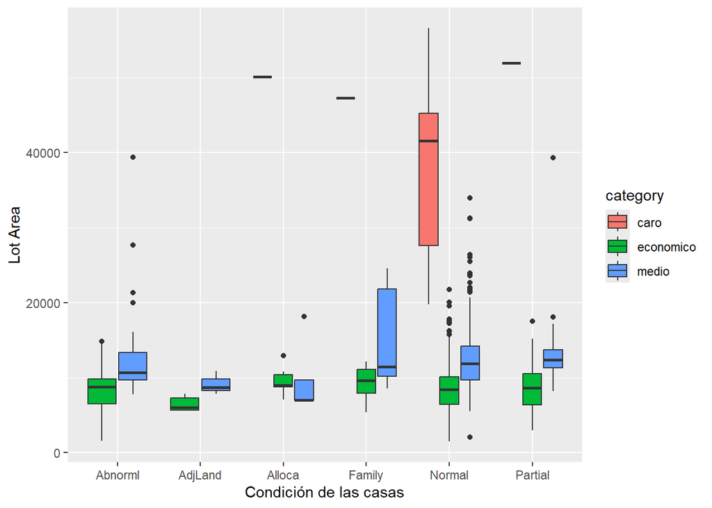

Se observa que las casas que tienen una condición de venta “Normal” son las más caras. En comparación, otras casas con diferentes condiciones tienden a ser económicas o de bajo costo. Aunque también se observa que la condición “Family” tiende a presentar un precio medio.

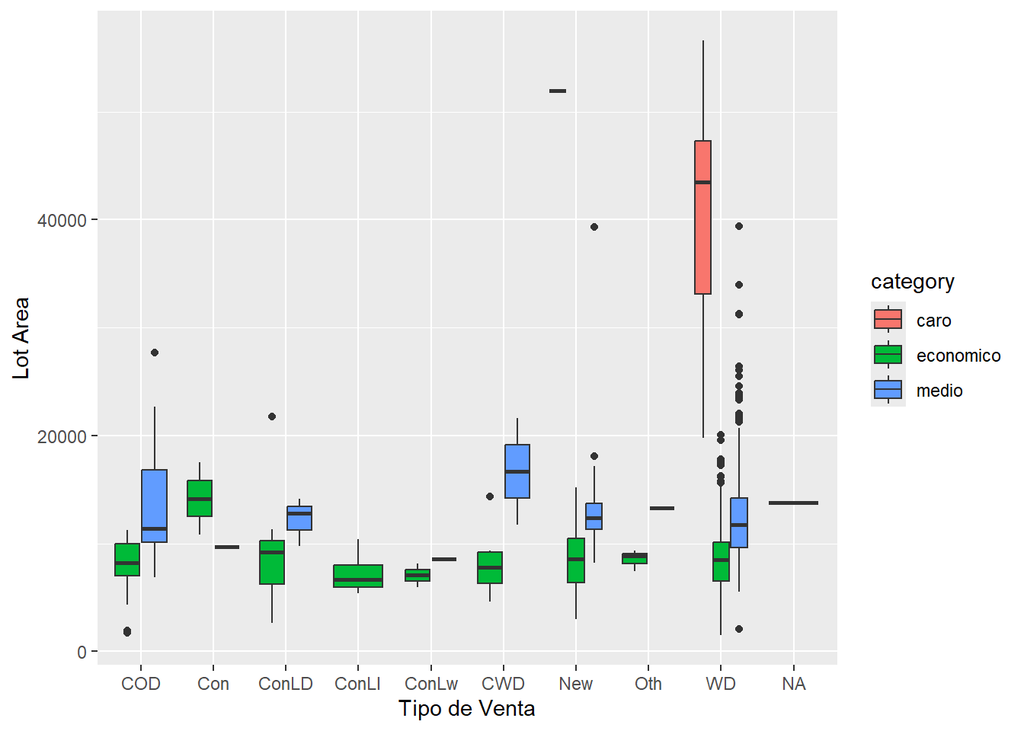

Se observa que las casas con escritura “WD” presentan un mayor rango de precios, concentrándose en viviendas caras y con áreas superiores a los 30,000 m². Sin embargo, también se identifican varios puntos atípicos en este grupo. Por otro lado, las propiedades con escritura tipo “COD” (escritura emitida por un funcionario judicial) tienden a ubicarse en un rango de entre 0 y 20,000 m², con precios mayormente medios y algunos económicos. Finalmente, las viviendas con tipo de venta “ConLI” (contrato con interés bajo) se asocian exclusivamente a casas económicas, sin presencia en los rangos de precio medio o alto.

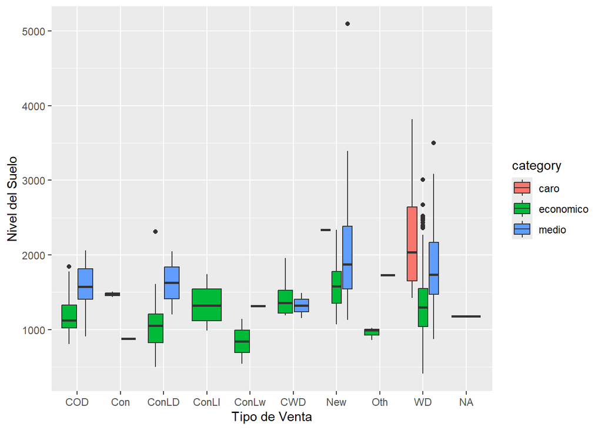

Se observa en este diagrama de caja y bigotes que la mayoría de las casas clasificadas como “caras” forman parte del tipo de venta “WD”, que corresponde a la transferencia mediante escritura. Por otro lado, las categorías “caro” y “medio” se encuentran en un rango similar, aunque “caro” presenta un rango más amplio. También se puede notar que dentro del criterio “WD” existen casos tanto económicos como de precio medio. Por otro lado, las casas vendidas bajo condiciones de menor interés (como “ConLI”) presentan un mayor volumen de viviendas económicas, lo cual resulta coherente con el tipo de financiación ofrecido.

En base a los datos explorados podemos observar o utilizar ciertas variables para generar el modelo SVM. A continuación se realizaran varios modelos tuneados de SVM para realizar comparaciones ante la eficiencia y exactitud de otros modelos.

```
##
##
## ========== MODELO 1: SVM LINEAL ==========
```

```
##
## ===== Resultados para SVM Lineal (C=1) =====
## Precisión en train: 96.38 %
## Precisión en test: 95.65 %
## Diferencia (train-test): 0.73 % puntos
##
## Matriz de confusión (datos de prueba):
##            Reference
## Prediction  caro economico medio
##   caro         2         1     1
##   economico    0       381     9
##   medio        0         8    35
##
## Diagnóstico: El modelo parece estar bien ajustado
```

```
##
##
## ========== MODELO 2: SVM POLINOMIAL ==========
```

```
##
## ===== Resultados para SVM Polinomial (grado=2, C=1) =====
## Precisión en train: 95.21 %
## Precisión en test: 94.51 %
## Diferencia (train-test): 0.7 % puntos
##
## Matriz de confusión (datos de prueba):
##            Reference
## Prediction  caro economico medio
##   caro         0         1     1
##   economico    1       383    14
##   medio        1         6    30
##
## Diagnóstico: El modelo parece estar bien ajustado
```

```
##
##
## ========== MODELO 3: SVM RADIAL ==========
```

```
##
## ===== Resultados para SVM Radial (gamma=0.1, C=1) =====
## Precisión en train: 97.07 %
## Precisión en test: 94.97 %
## Diferencia (train-test): 2.1 % puntos
##
## Matriz de confusión (datos de prueba):
##            Reference
## Prediction  caro economico medio
##   caro         0         0     0
##   economico    0       382    12
##   medio        2         8    33
##
## Diagnóstico: El modelo parece estar bien ajustado
```

```
##
##
## ========== MODELO 4: SVM RADIAL CON MAYOR REGULARIZACIÓN ==========
```

```
##
## ===== Resultados para SVM Radial Regularizado (gamma=0.01, C=0.5) =====
## Precisión en train: 94.92 %
## Precisión en test: 95.42 %
## Diferencia (train-test): -0.51 % puntos
##
## Matriz de confusión (datos de prueba):
##            Reference
## Prediction  caro economico medio
##   caro         0         0     0
##   economico    0       383    11
##   medio        2         7    34
##
## Diagnóstico: El modelo parece estar bien ajustado
```

En todos los modelos, las equivocaciones parecen ser entre las casas economicas y las de precio medio. Todos estas equivocaciones son leves, ya que los precios que comprenden estas categorias son bastante cercanos, por lo cual equivocaciones en estos campos. Para las casas caras, los modelos parecen tener equivocaciones entre las casas caras y medias. El unico modelo que fue capaz de identificar correctamente las casas caras fue el SMV linear con c = 1.

```
##                    Modelo Precisión_Train Precisión_Test   Diferencia
## 1              SVM Lineal       0.9638319      0.9565217  0.007310128
## 2          SVM Polinomial       0.9521017      0.9450801  0.007021570
## 3              SVM Radial       0.9706745      0.9496568  0.021017736
## 4 SVM Radial Regularizado       0.9491691      0.9542334 -0.005064299
```

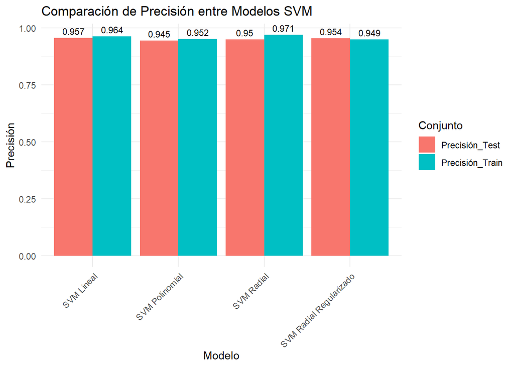

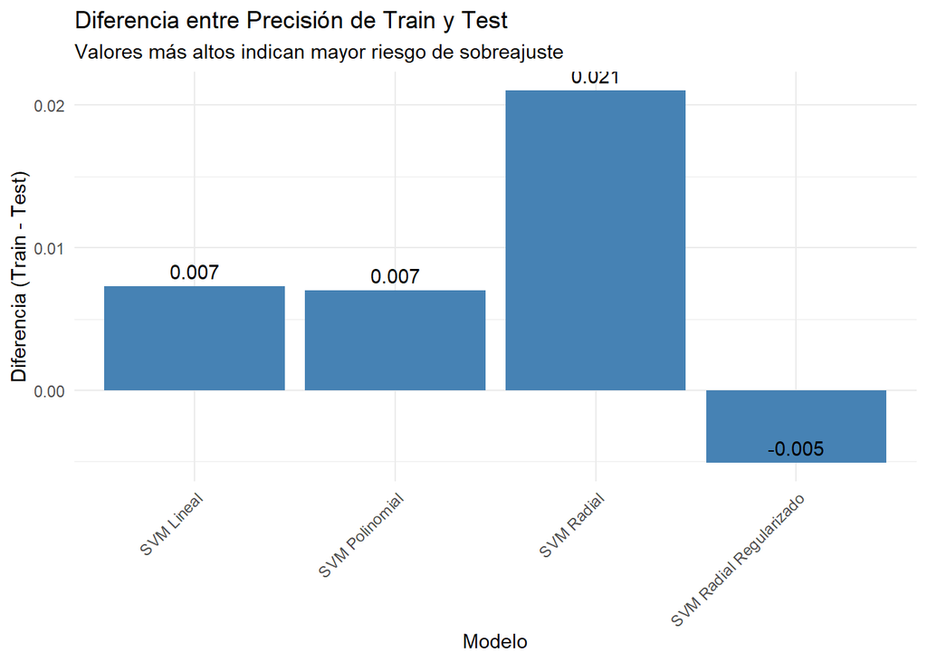

```
## El mejor modelo según precisión en validación es: SVM Lineal
```

Todos los modelos parecen tener una precision demasiado alta, lo que podria ser indicador de sobreajuste, pero el modelo con la mayor diferencia de precision (y la precision mas alta) parece ser el SVM Radial. Para manejar posibles sobreajustes se podria:

- Reducir la complejidad del modelo (con menor gamma o grado polinomial)
- Aumentar la regularizacion
- Reducir el numero de variables predictoras
- Usar validacion cruzada

Al observar la eficiencia de diferentes modelos podemos notar que hay algunos más eficientes que el modelo SVM pero, el modelo SVM se puede realizar un tuneo con la finalidad de observar si es más eficientes o mejor que otros modelos. A continuación se realizará el tuneo de SVM lineal y realizar la comparación ante modelos como KNN, naive Byaes con el criterio del menor RMSE.

```
## [1] 70803.9
```

Al normalizar los datos y reemplazar valores NA´s observamos que el RMSE del modelo SVM lineal está en los rangos adecuados de otros modelos pero se observa en un momento que este no es un modelo con el menor RMSE.

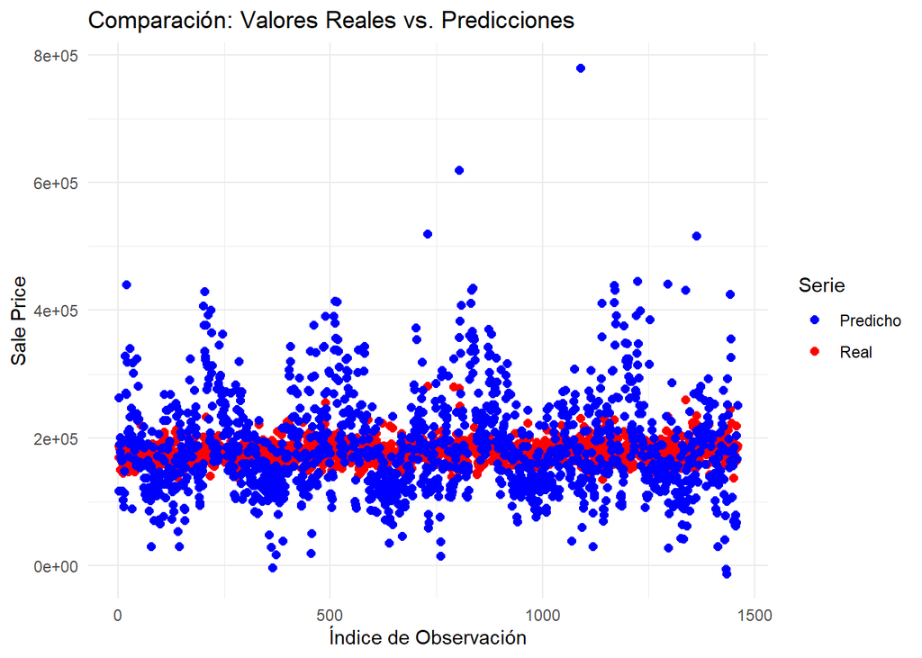

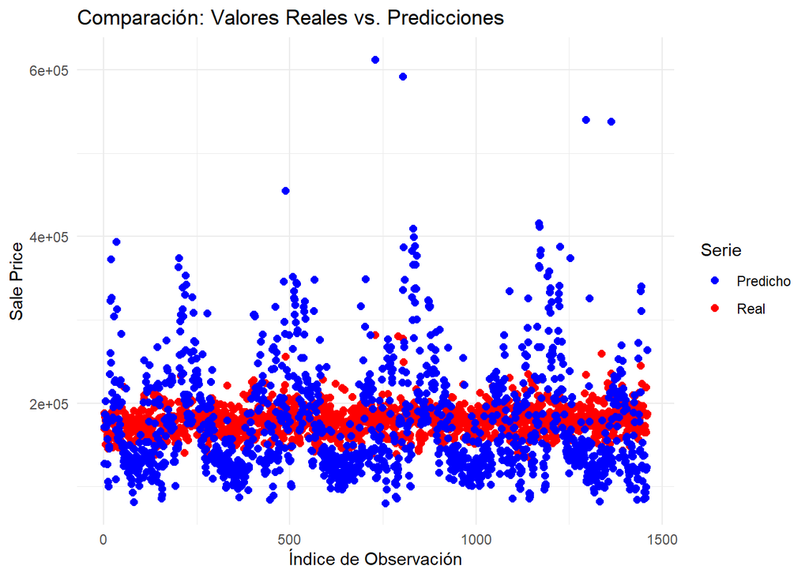

```r
 RMSE(predModelo3, datos$SalePrice)
```

```
## [1] 62053.9
```

El modelo a utilizar es Naive Bayes donde a continucación se presentara la gráfica y su RMSE.

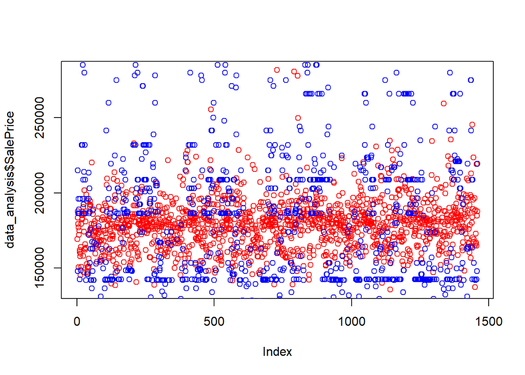

Se observa en la gráfica que no es un modelo tán optimo ya que presenta algunos datos con sobreajuste pero existen otros datos que no están sobreajustados.

```r
 RMSE(predBayes, datos$SalePrice)
```

```
## [1] 70237.08
```

Por otro lado vemos que el RMSE es menor que SVM lineal. Aunque no es uno de los mejores modelos, en el siguente modelo a comparar observamos el mayor RMSE y sobreajuste de datos.

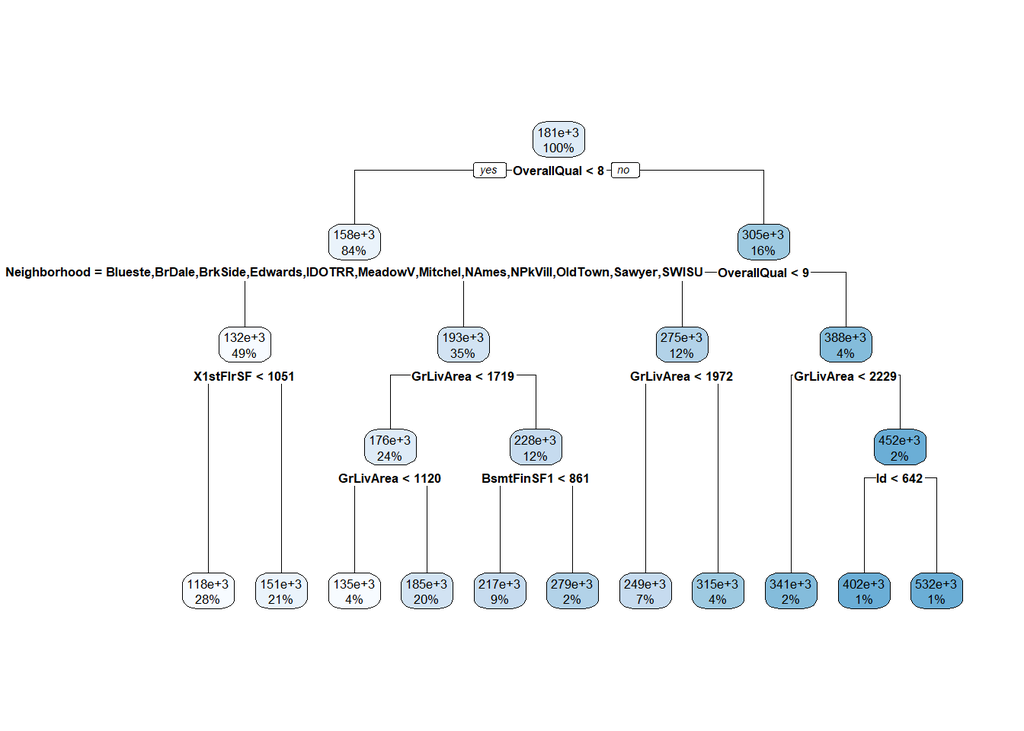

El modelo presentado es un árbol de decisión en la cual tenemos 4 niveles de comparación. Además en se observa que RMSE es el mayor de todos los modelos presentados.

```
## [1] 77161.11
```

se observa que el rmse del modelo de prueba es de 77161.11 lo cual sus valores son muy altos lo cual puede indicar un overfitting de los datos como se muestra en la siguiente gráfica.

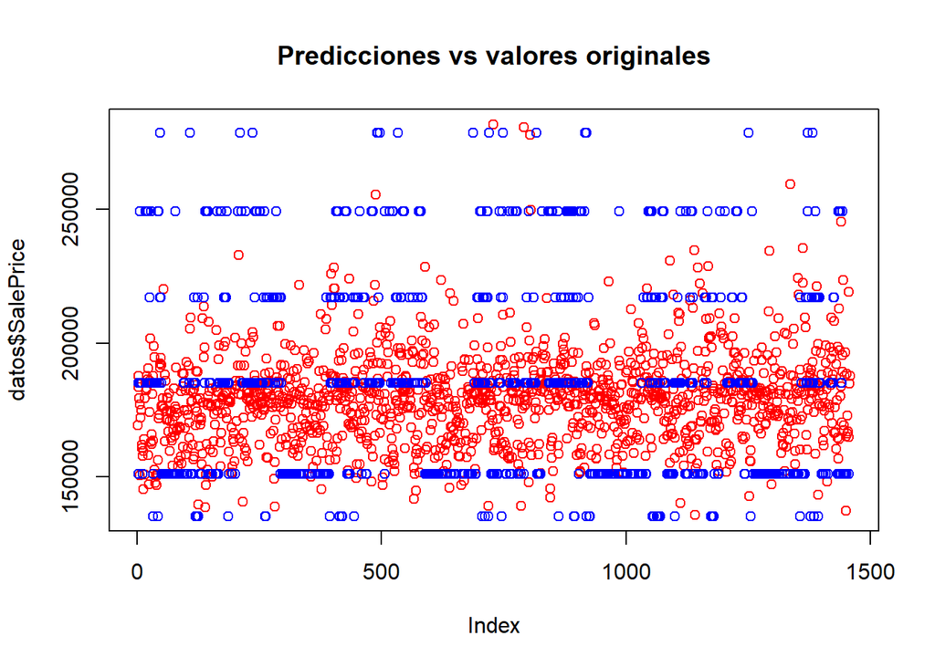

```r
fitLMPW<-lm(SalePrice~LotArea, data = train_data)
```

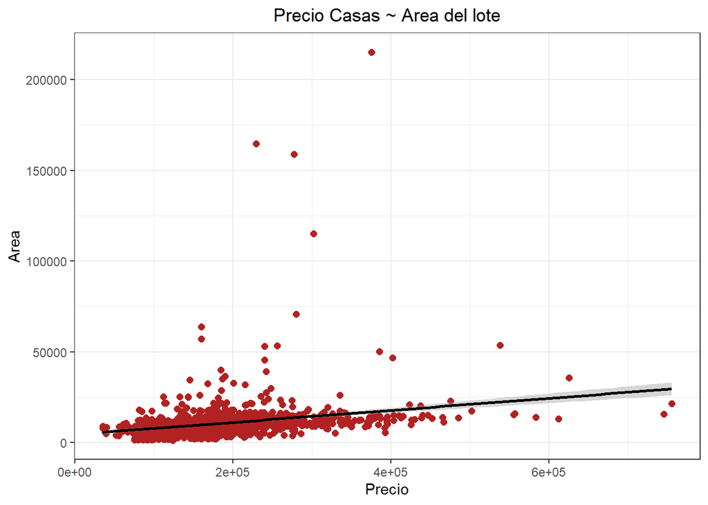

```r
ggplot(data = train_data, mapping = aes(x = SalePrice, y = LotArea)) +
geom_point(color = "firebrick", size = 2) +
geom_smooth(method = "lm", se = TRUE, color = "black") +
labs(title = "Precio Casas ~ Area del lote", x = "Precio", y = "Area") +
theme_bw() + theme(plot.title = element_text(hjust = 0.5))
```

Usando esta ecuación podemos predecir la Venta de casa para el conjunto de prueba.

```r
predL<-predict(fitLMPW, newdata = datos)
```

```r
RMSE(predL, price$SalePrice)
```

```
## [1] 11620.85
```

```r
head(predL)
```

```
##        1        2        3        4        5        6
## 183242.0 188796.5 187878.8 179789.7 169346.5 179835.9
```

```r
length(predL)
```

```
## [1] 1459
```

Para saber que tan bueno es el modelo para predecir dados los datos de entrenamiento se deben analizar los residuos. Estos no pueden seguir ningún patrón, es decir que deben ser aleatorios alrededor de 0. Deben estar distribuidos normalmente.

```r
head(fitLMPW$residuals)
```

```
##          1          2          3          4          5          6
##  31919.085   2504.117  41039.164 -38890.884  61218.248 -45477.256
```

En los siguientes gráficos se pueden analizar los residuales.

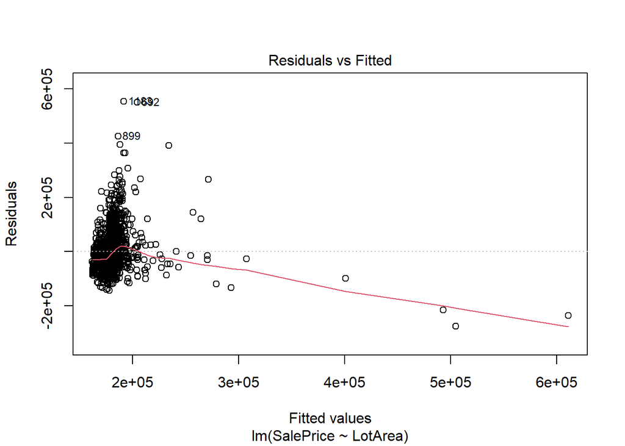

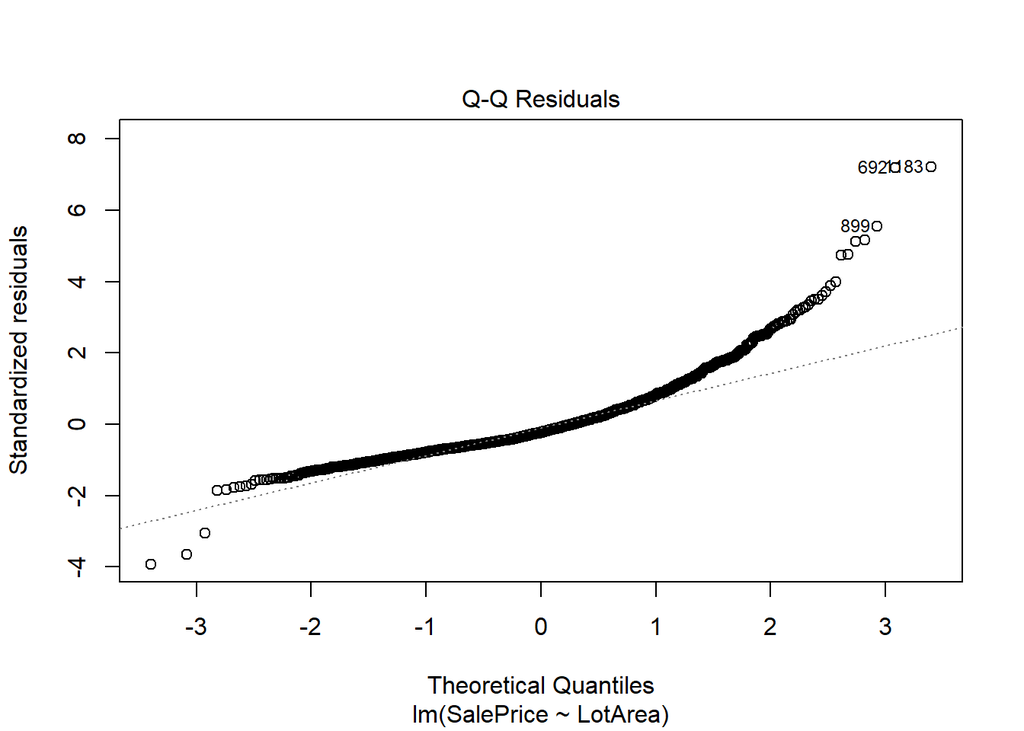

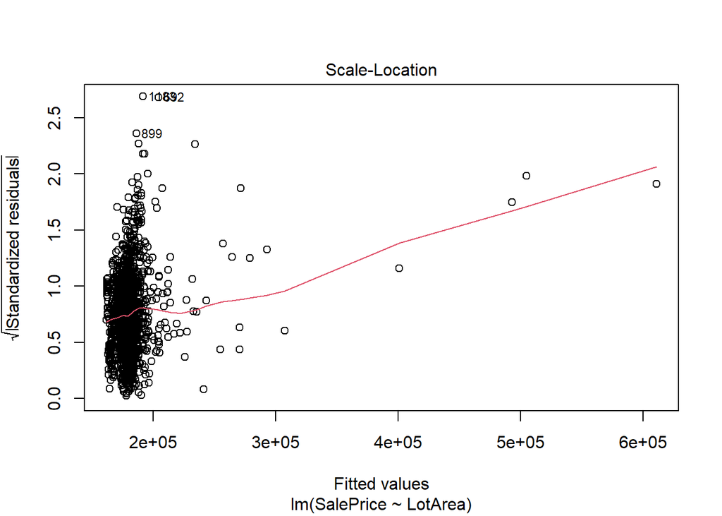

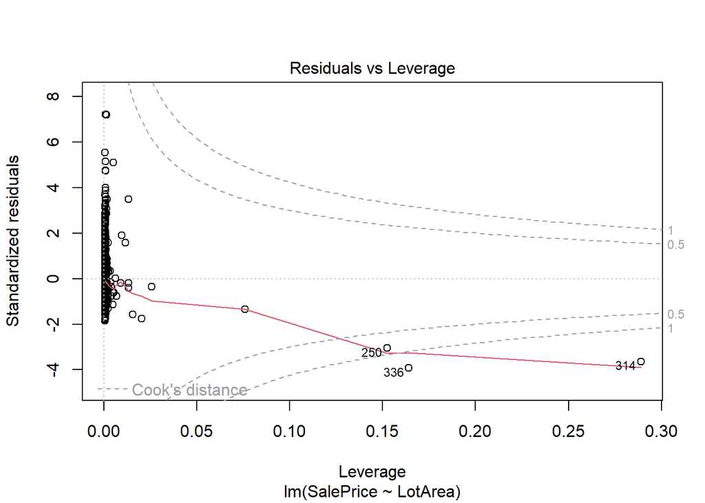

```r
plot(fitLMPW)
```

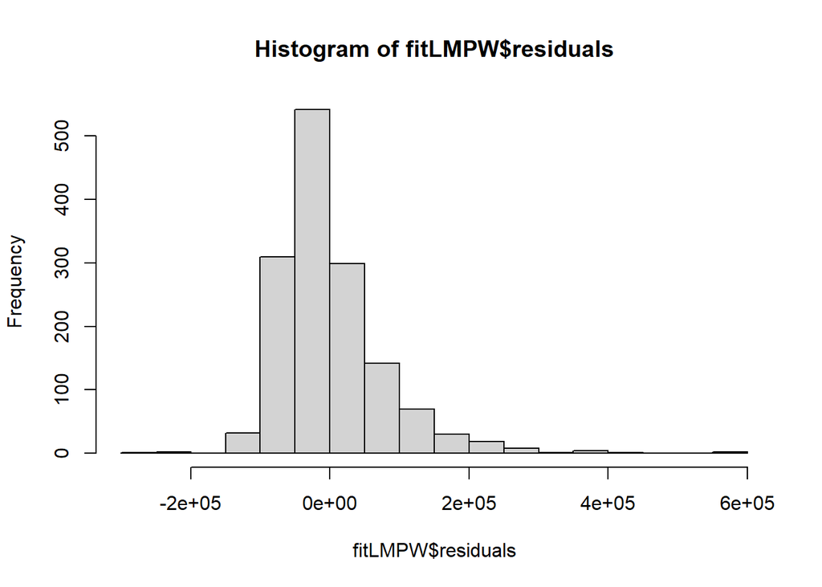

```r
hist(fitLMPW$residuals)
```

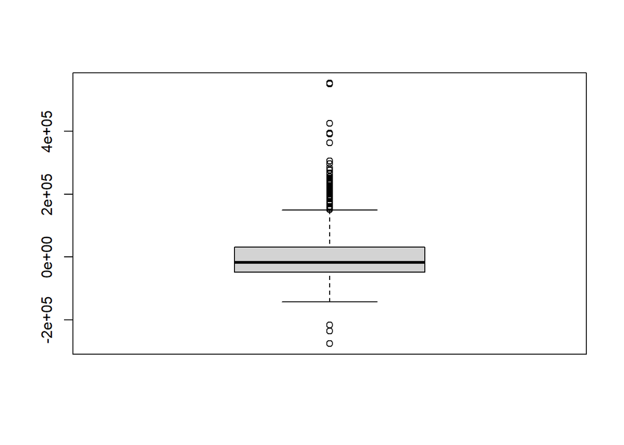

```r
boxplot(fitLMPW$residuals)
```

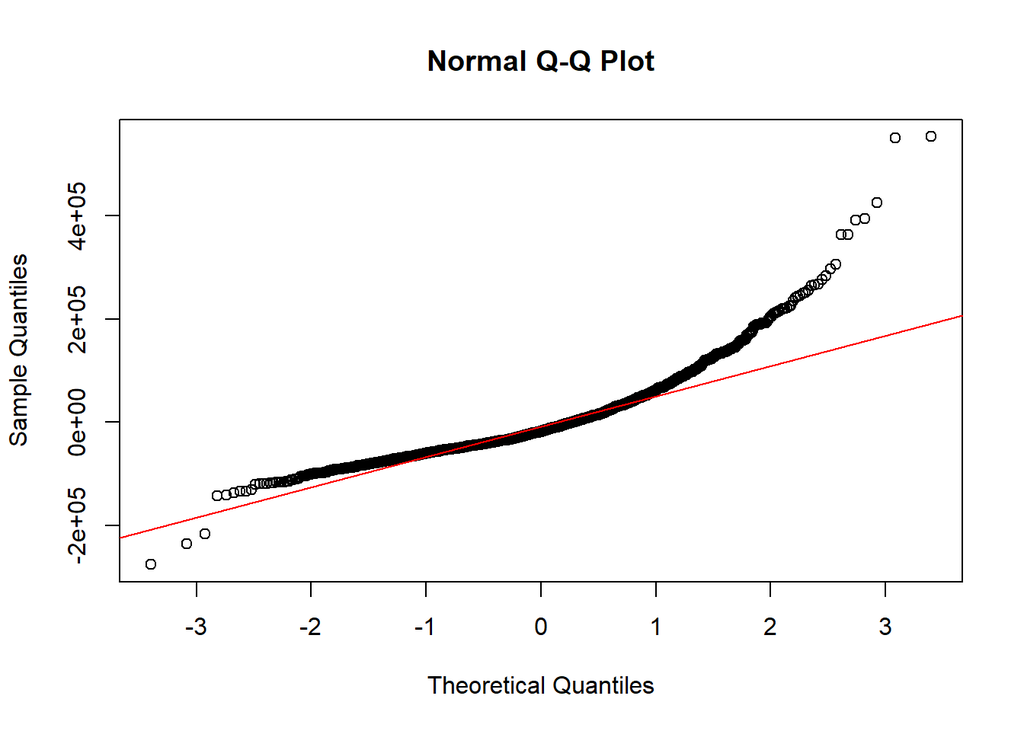

```r
qqnorm(fitLMPW$residuals)
qqline(fitLMPW$residuals, col="red")
```

```
##     Id SalePrice economico medio caro
## 1 1461  169277.1         1     0    0
## 2 1462  187758.4         0     1    0
## 3 1463  183583.7         1     0    0
## 4 1464  179317.5         1     0    0
## 5 1465  150730.1         1     0    0
## 6 1466  177151.0         1     0    0
```

```
##   Id MSSubClass MSZoning LotFrontage LotArea Street Alley LotShape LandContour
## 1  1         60       RL          65    8450   Pave  <NA>      Reg         Lvl
## 2  2         20       RL          80    9600   Pave  <NA>      Reg         Lvl
## 3  3         60       RL          68   11250   Pave  <NA>      IR1         Lvl
## 4  4         70       RL          60    9550   Pave  <NA>      IR1         Lvl
## 5  5         60       RL          84   14260   Pave  <NA>      IR1         Lvl
## 6  6         50       RL          85   14115   Pave  <NA>      IR1         Lvl
##   Utilities LotConfig LandSlope Neighborhood Condition1 Condition2 BldgType
## 1    AllPub    Inside       Gtl      CollgCr       Norm       Norm     1Fam
## 2    AllPub       FR2       Gtl      Veenker      Feedr       Norm     1Fam
## 3    AllPub    Inside       Gtl      CollgCr       Norm       Norm     1Fam
## 4    AllPub    Corner       Gtl      Crawfor       Norm       Norm     1Fam
## 5    AllPub       FR2       Gtl      NoRidge       Norm       Norm     1Fam
## 6    AllPub    Inside       Gtl      Mitchel       Norm       Norm     1Fam
##   HouseStyle OverallQual OverallCond YearBuilt YearRemodAdd RoofStyle RoofMatl
```

[output cut: 76 more lines]

Se realiza la eliminación de datos NA´s dentro del dataset con la finalidad de tener más precisión y exactitud en los modelos.

```
##     Id MSSubClass MSZoning LotFrontage LotArea Street Alley LotShape
## 1 1461         20       RH          80   11622   Pave  Grvl      Reg
## 2 1462         20       RL          81   14267   Pave  Grvl      IR1
## 3 1463         60       RL          74   13830   Pave  Grvl      IR1
## 4 1464         60       RL          78    9978   Pave  Grvl      IR1
## 5 1465        120       RL          43    5005   Pave  Grvl      IR1
## 6 1466         60       RL          75   10000   Pave  Grvl      IR1
##   LandContour Utilities LotConfig LandSlope Neighborhood Condition1 Condition2
## 1         Lvl    AllPub    Inside       Gtl        NAmes      Feedr       Norm
## 2         Lvl    AllPub    Corner       Gtl        NAmes       Norm       Norm
## 3         Lvl    AllPub    Inside       Gtl      Gilbert       Norm       Norm
## 4         Lvl    AllPub    Inside       Gtl      Gilbert       Norm       Norm
## 5         HLS    AllPub    Inside       Gtl      StoneBr       Norm       Norm
## 6         Lvl    AllPub    Corner       Gtl      Gilbert       Norm       Norm
##   BldgType HouseStyle OverallQual OverallCond YearBuilt YearRemodAdd RoofStyle
```

[output cut: 76 more lines]

```
## Confusion Matrix and Statistics
##
##            Reference
## Prediction  economico medio caro
##   economico      1010   436    3
##   medio             0     3    7
##   caro              0     0    0
##
## Overall Statistics
##
##                Accuracy : 0.6943
##                  95% CI : (0.67, 0.7179)
##     No Information Rate : 0.6923
##     P-Value [Acc > NIR] : 0.445
##
##                   Kappa : 0.0153
##
##  Mcnemar's Test P-Value : <2e-16
##
## Statistics by Class:
##
##                      Class: economico Class: medio Class: caro
## Sensitivity                   1.00000     0.006834    0.000000
## Specificity                   0.02227     0.993137    1.000000
## Pos Pred Value                0.69703     0.300000         NaN
## Neg Pred Value                1.00000     0.699103    0.993146
## Prevalence                    0.69225     0.300891    0.006854
## Detection Rate                0.69225     0.002056    0.000000
## Detection Prevalence          0.99315     0.006854    0.000000
## Balanced Accuracy             0.51114     0.499985    0.500000
```

```
## Confusion Matrix and Statistics
##
##           Reference
## Prediction    1    2    3
##          1    0    0    0
##          2   10 1010  439
##          3    0    0    0
##
## Overall Statistics
##
##                Accuracy : 0.6923
##                  95% CI : (0.6679, 0.7159)
##     No Information Rate : 0.6923
##     P-Value [Acc > NIR] : 0.5128
##
##                   Kappa : 0
##
##  Mcnemar's Test P-Value : NA
##
## Statistics by Class:
##
##                      Class: 1 Class: 2 Class: 3
## Sensitivity          0.000000   1.0000   0.0000
## Specificity          1.000000   0.0000   1.0000
## Pos Pred Value            NaN   0.6923      NaN
## Neg Pred Value       0.993146      NaN   0.6991
## Prevalence           0.006854   0.6923   0.3009
## Detection Rate       0.000000   0.6923   0.0000
## Detection Prevalence 0.000000   1.0000   0.0000
## Balanced Accuracy    0.500000   0.5000   0.5000
```

Se observa a continuación que el modelo y el modelo anterior tuvieron una exactitud cercana a 69% ya que se debe al desbalance en la variable objetivo. La mayoría de las predicciones son asignadas a la clase “económico”, lo cual refleja un modelo sesgado hacia la clase que tiene la mayoria de los datos. La métrica Kappa cercana a cero respalda que el modelo no logra una clasificación útil más allá de lo que se obtendría por azar. Como habia mencionado con anterioridad, esto se debe al desbalance en los datos donde representa que la mayoria de los datos son económicos.

La baja exactitud de los modelos muestra que estos no cuentan con sobreajuste, si no que estan mal ajustados y tienen desbalance en la informacion.

Para mejorar el muestreo se realizaran tuneos para el primer modelo (caret).

Una vez utilizado la variable respuesta category, seleccionaremos la variable SalePrice para comparar si tiene una mejor exactitud el modelo con otros modelos que utilizamos para la variable respuesta SalePrice.

[output not shown]

[output not shown]

```
## [1] 75804.77
```

```
## [1] 1.376887
```

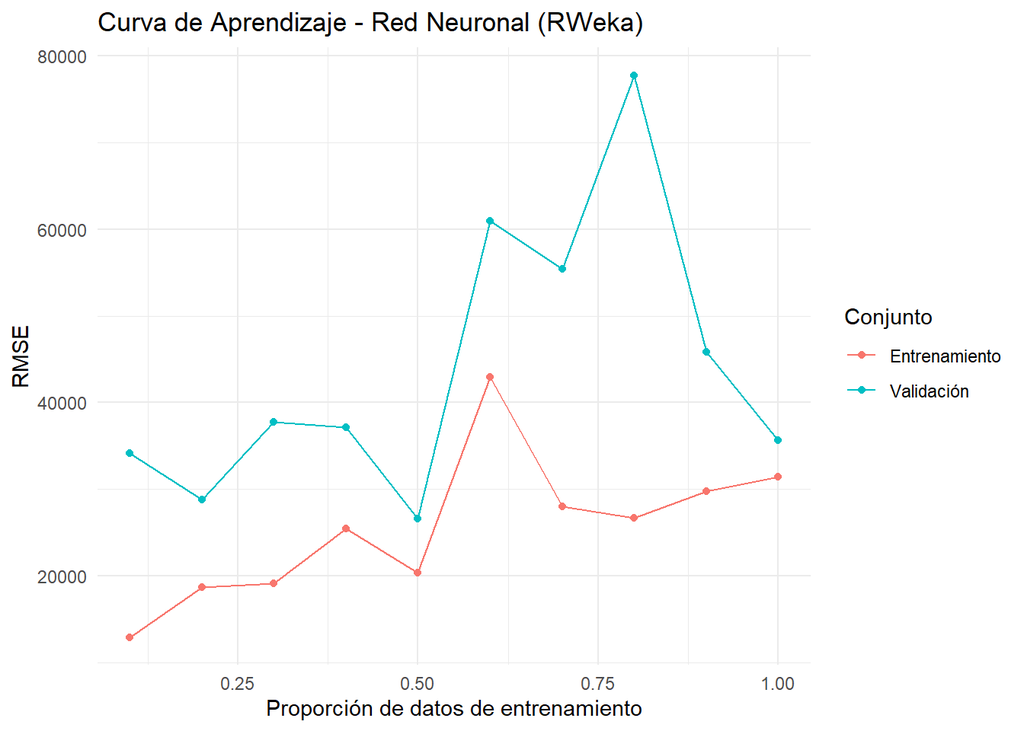

```
## [1] 172911.2
```